# ROC#10 Getting Fancy with ggplot2

Grace Deitzler

2023-02-24

## First steps

Set your working directory to the folder that contains this file and the iris csv.

## ggplot Intro

### What is ggplot?

ggplot2, or ‘grammar of graphics’ plot, is a package in R that can be used to make elegant and highly customizable data visualizations. ggplot2 was developed by Hadley Wickham, whose sister Charlotte is an instructor in the stats department here at Oregon State.

You provide ggplot with data, and use ggplot syntax to map variables from that data to aesthetics. You create ggplot in layers, and this way you can easily add things like colors, titles, plot types, axis text, orientations, and myriad other specifications.

ggplot2 has a fairly steep learning curve, but once you get the basics down, you can begin to make beautiful and informative plots.

The R for Data Science book has a great primer on getting started with ggplot: https://r4ds.had.co.nz/data-visualisation.html

## ggplot2 basics

Let’s make a very simple plot using the iris dataset.

```r
iris <- read.csv("iris.csv")

#check it out

View(iris)
```

Starting with a basic barplot.

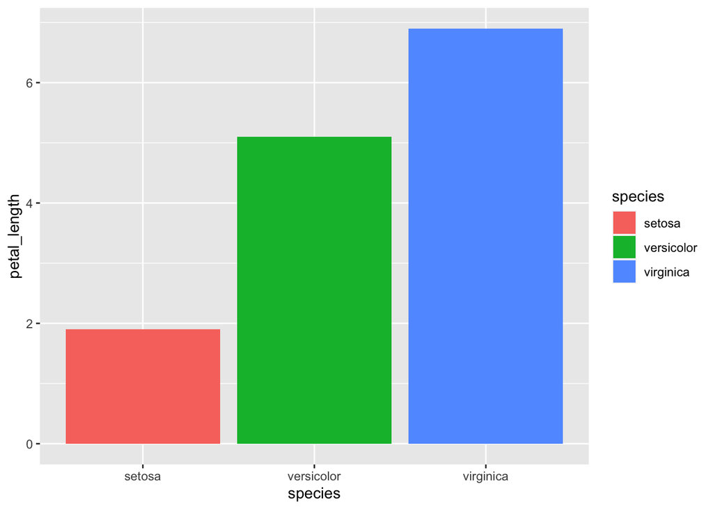

```r
ggplot(iris) + #here, we are calling the ggplot function and giving it the iris dataset
  geom_bar(aes(x = species, y = petal_length, fill = species), #now, we add on the layer that specifies that you want to make a barplot, and which variables you want for your x and y axis
           stat = "identity", position = "dodge") #this line is specific to the geom_bar function - some plot types have ways you can further customize them in a separate layer
```

Now for some fun stuff…

## Making a Custom Color Palette

I like to start by generating a palette using a website like coolors.co.

Before deciding on a palette, check to make sure that your selected colors can be easily seen by those with colorblindness. You can use the Coblis website https://www.color-blindness.com/coblis-color-blindness-simulator/ to upload a screenshot of your chosen color palette to see how it will look with different kinds of colorblindness.

Once you have your palette in mind, copy and paste the color names and hex codes, which we will store as a list, and then create a function to call the colors in the list.

```r
#named vector of hex codes
my_colors <- c('Yellow Orange' = "#FFA630",
                    'Tea Green' = "#D7E8BA",
                    'Cadet Blue' = "#4DA1A9",
                    'Coral' = "#EF6F6C",
                    'Sage' = "#BBC385",
                    'Hyacinth' = '#94579E'


)
#function to access the colors
my_cols <- function(...) {
  cols <- c(...)

  if (is.null(cols))
    return (my_colors)

  my_colors[cols]
}

#test - does the function work?

my_cols("Sage")
```

```
##      Sage
## "#BBC385"
```

```r
#named lists of different palettes - which are all combinations of the colors we named above
my_palette <- list(
  'main' = my_cols("Yellow Orange", "Coral", "Cadet Blue"),
  'two' = my_cols("Hyacinth", "Sage"),
  'three' = my_cols("Hyacinth", "Sage", "Tea Green")
)

# now a function to access the palettes above
my_pal <- function(palette = "main", reverse = FALSE, ...) {
  pal <- my_palette[[palette]]

  if (reverse) pal <- rev(pal)

  colorRampPalette(pal, ...)
}

#now build ggplot2 compatible scale functions for color and fill that use the palettes
scale_color_mycolors <- function(palette = "main", discrete = TRUE, reverse = FALSE, ...) {
  pal <- my_pal(palette = palette, reverse = reverse)

  if (discrete) {
    discrete_scale("colour", paste0("my_", palette), palette = pal, ...)
  } else {
    scale_color_gradientn(colours = pal(256), ...)
  }
}

scale_fill_mycolors <- function(palette = "main", discrete = TRUE, reverse = FALSE, ...) {
  pal <- my_pal(palette = palette, reverse = reverse)

  if (discrete) {
    discrete_scale("fill", paste0("my_", palette), palette = pal, ...)
  } else {
    scale_fill_gradientn(colours = pal(256), ...)
  }
}
```

Let’s test it on the Iris dataset.

Let’s add in our colors in place of the default

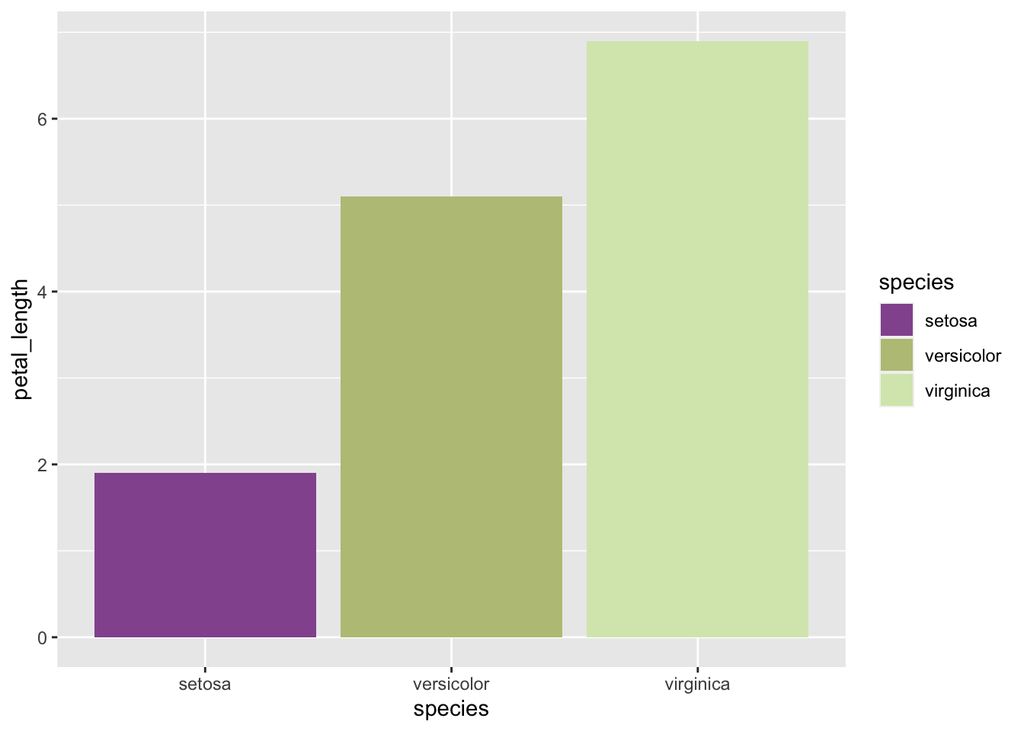

```r
ggplot(iris) +
  geom_bar(aes(x = species, y = petal_length, fill = species),
           stat = "identity", position = "dodge") +
  scale_fill_mycolors(palette = "three")
```

Looks good! Now let’s clean it up a bit: add axis lables/title, increase the font size to make it more readable. I’m going to remove the axis lines and ticks just for fun here too.

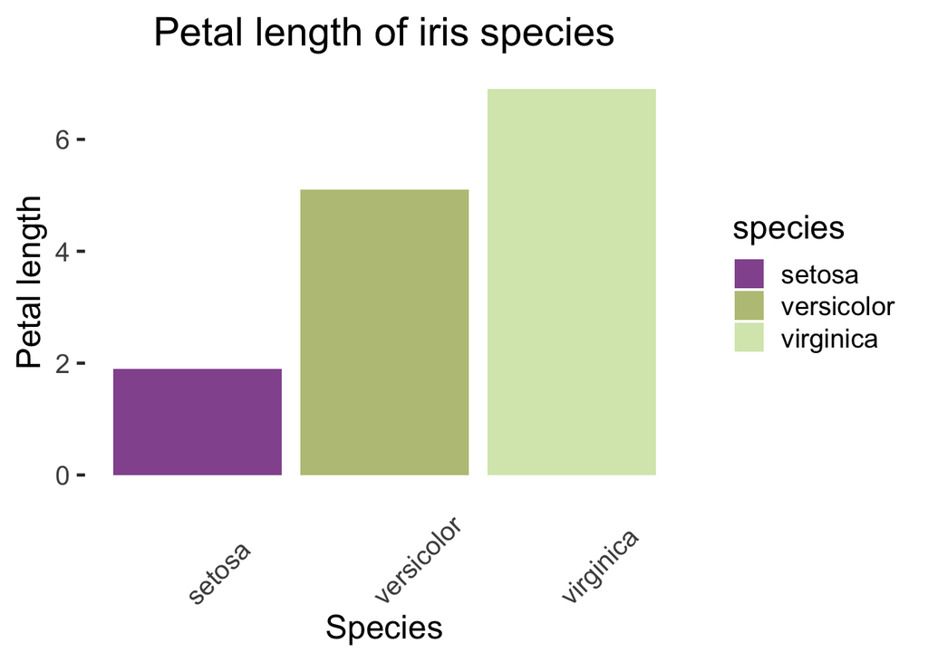

```r
# make a bar plot for petal length

ggplot(iris) +
  geom_bar(aes(x = species, y = petal_length, fill = species),
           stat = "identity", position = "dodge") +
  scale_fill_mycolors(palette = "three") +
  theme_classic(base_size = 18) + #changing the grey default scheme as well as increasing the text size
  xlab("Species") +
  ylab("Petal length") +
  theme(axis.text.x = element_text(angle = 45,
                                   hjust = 0, vjust = 0),
        axis.line = element_blank(), #removing the axis lines
        axis.ticks.x = element_blank()) + #removing the axis ticks along the x axis
          ggtitle("Petal length of iris species") +
  theme(plot.title = element_text(hjust = 0.5)) # center the text
```

Looks like the color function worked!

## Playing around with themes

Viewing them side by side to get a feel for the differences

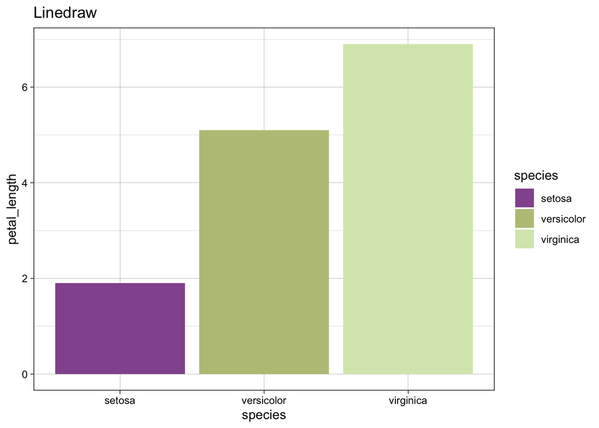

```r
# let's save the above code as an object so we can easily add themes

p <- ggplot(iris) +
  geom_bar(aes(x = species, y = petal_length, fill = species),
           stat = "identity", position = "dodge") +
  scale_fill_mycolors(palette = "three")

p + theme_linedraw() + ggtitle("Linedraw")
```

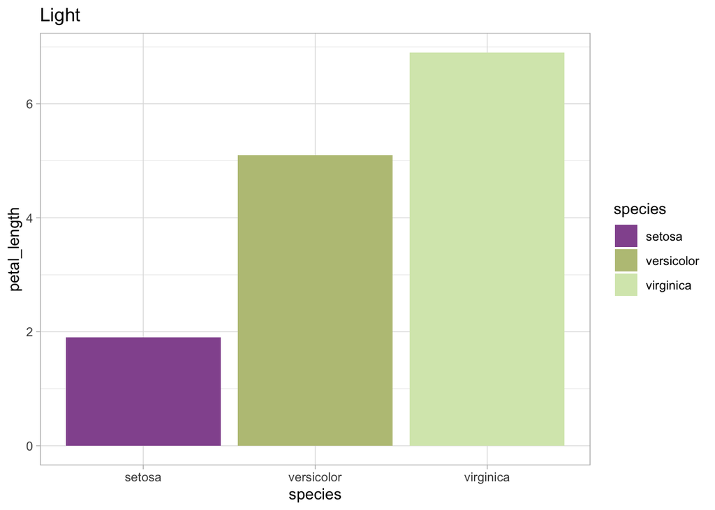

```r
p + theme_light() + ggtitle("Light") # similar to above
```

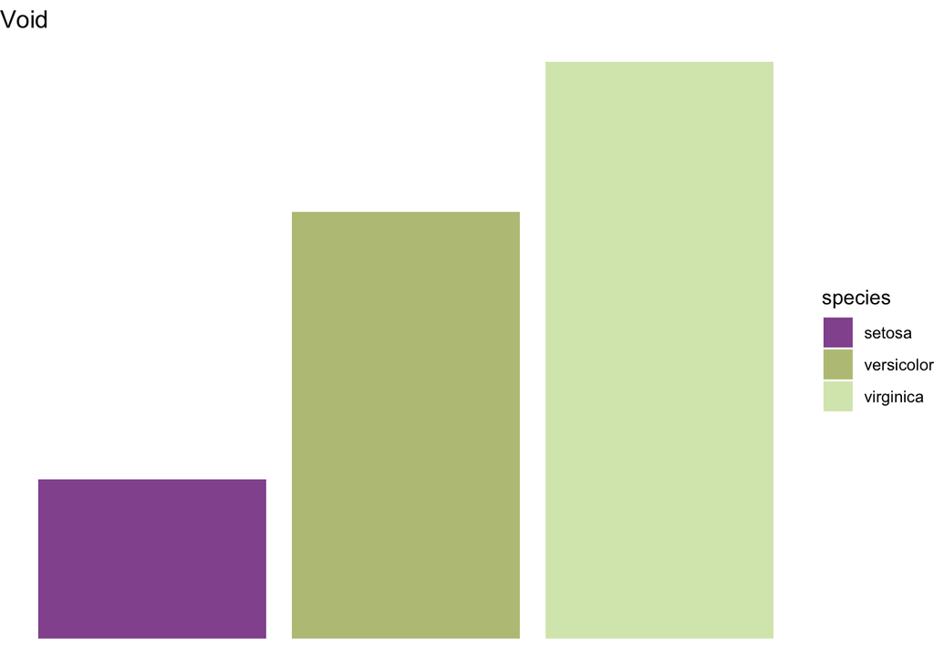

```r
p + theme_void() + ggtitle("Void") #when you want no text, for some reason
```

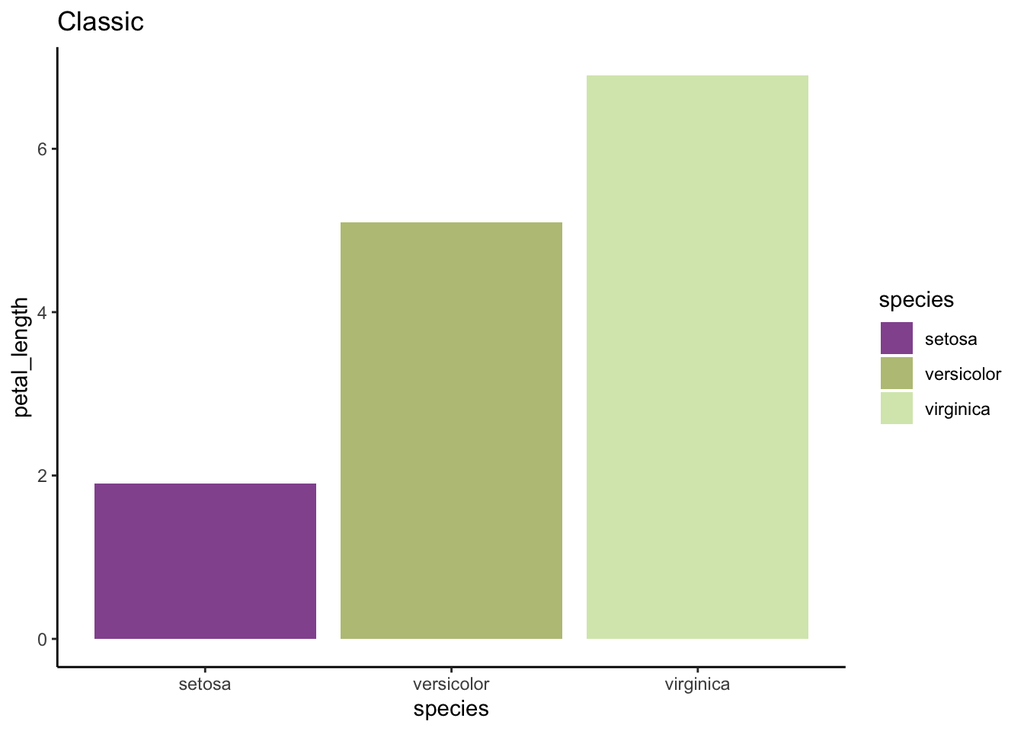

```r
p + theme_classic()+ ggtitle("Classic")
```

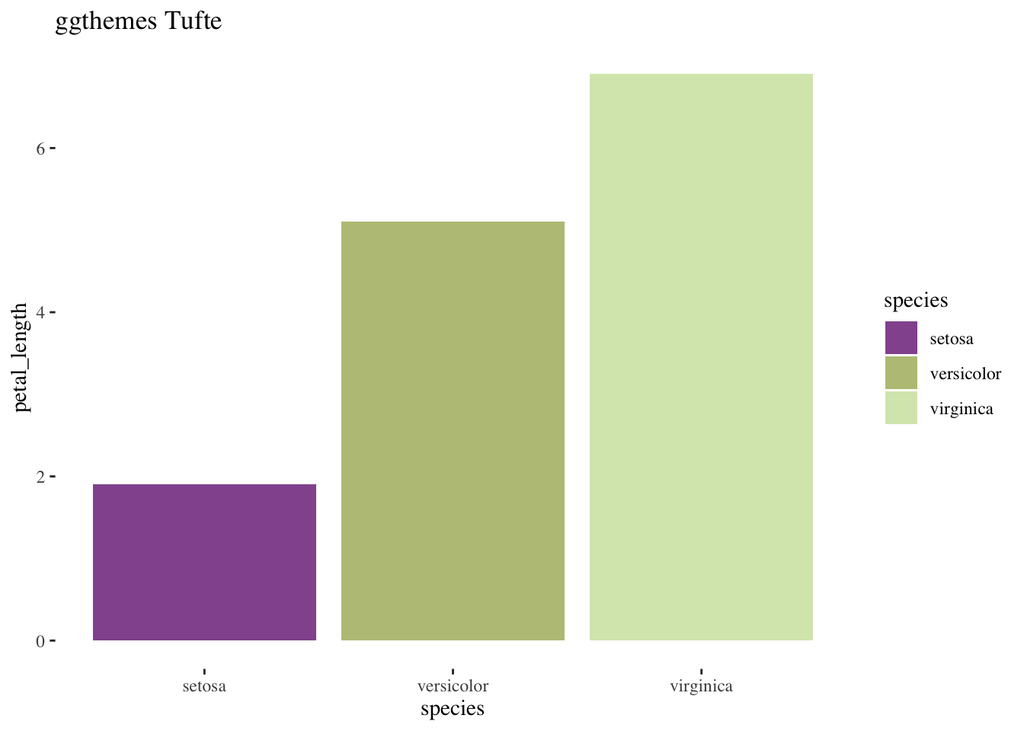

```r
p + theme_tufte() + ggtitle("ggthemes Tufte") #minimalist, with Times New Roman font
```

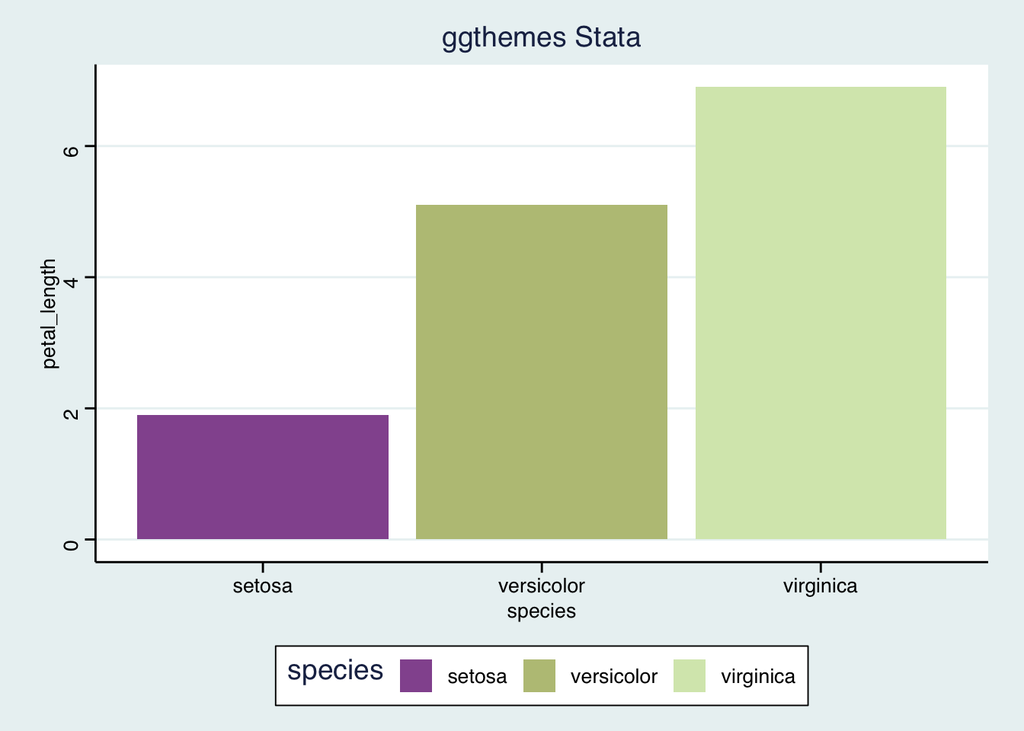

```r
p + theme_stata() + ggtitle("ggthemes Stata")#I like this one for presentations, very crisp
```

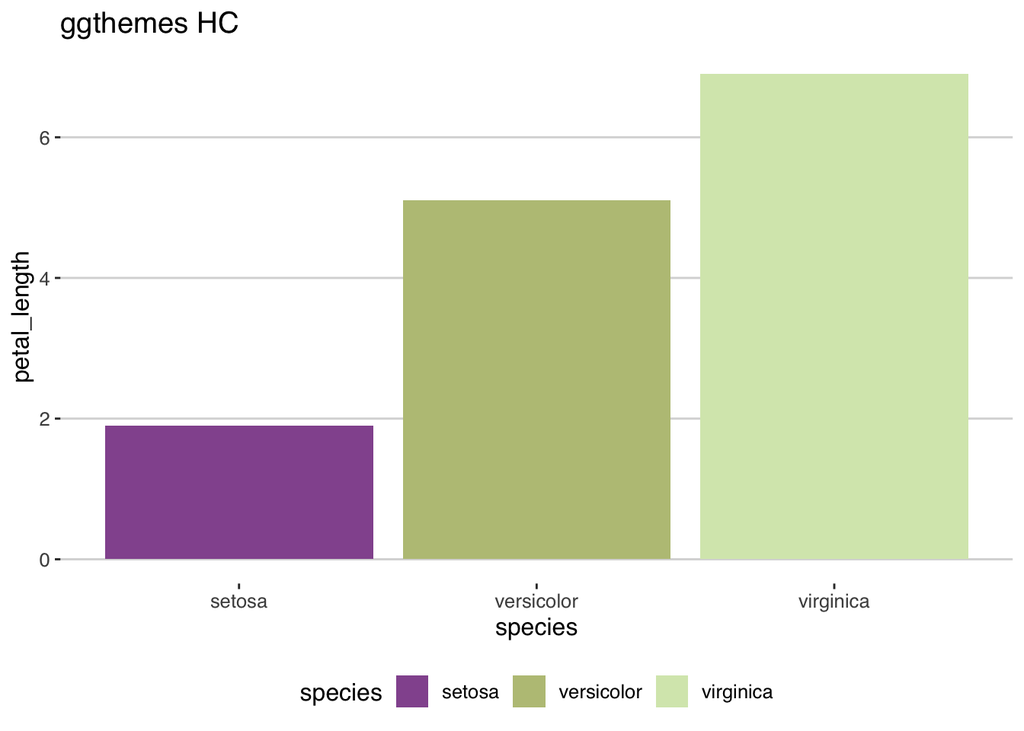

```r
p + theme_hc() + ggtitle("ggthemes HC")#another nice one for presentations
```

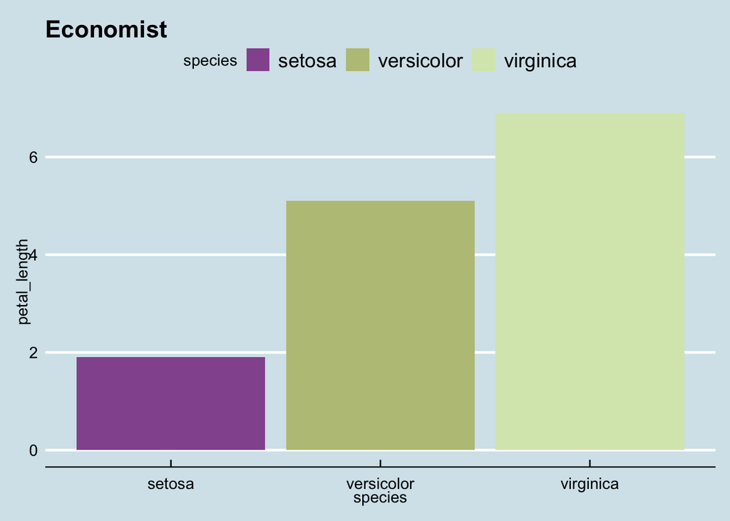

```r
p + theme_economist() + ggtitle("Economist")
```

here you could also fill in the "_" with the hex code of your poster color, which can be obtained by using a color picker in PowerPoint, Paint, or a similar image editing software.

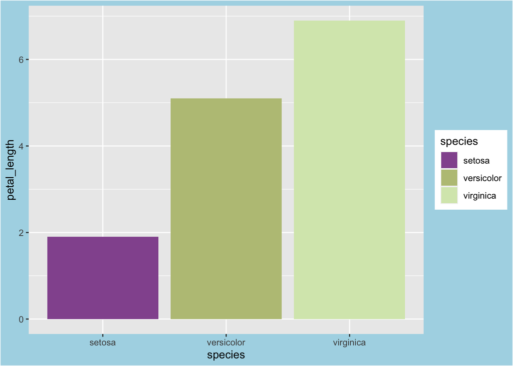

```r
p + theme(
  plot.background = element_rect(fill = "lightblue")
)
```

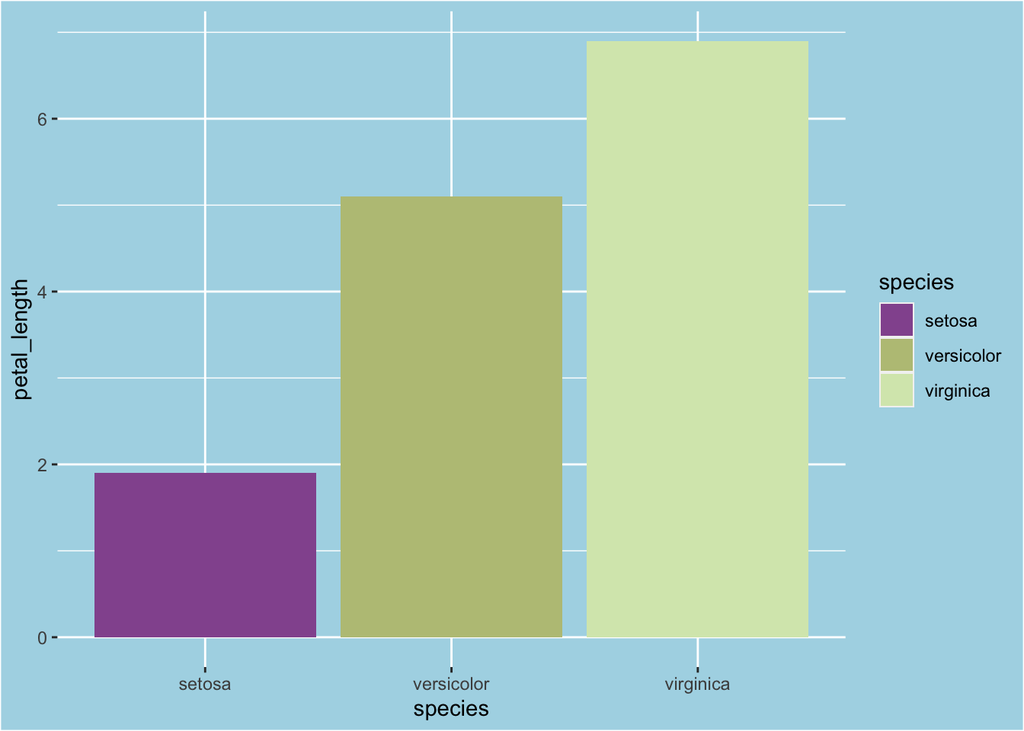

```r
# can also change the color of the panel

p + theme(
  plot.background = element_rect(fill = "lightblue"), #plot
  panel.background = element_rect(fill = "lightblue"), #panel
  legend.background = element_rect(fill = "lightblue") #legend
)
```

A final word on themes: you can also save and create your own custom theme! This way it can be saved so you can apply it to every plot you make (especially nice if you’re making a presentation or poster.) You can also set the theme at the start of your script by specifying what theme you want with the following syntax: theme_set(theme_bw()) #change depending on your theme name

I’m going to make a purple one just because.

[figure not shown]

```r
theme_lavender <- function(base_size = 12, base_family = "sans"){
  theme(
    plot.background = element_rect(fill = "#E6CAEB"),
    panel.grid.major = element_line(color = "grey"),
    panel.background = element_rect(fill = "#E6CAEB"),
    panel.border = element_rect(color = "#E6CAEB"),
     legend.background = element_rect(fill = "#E6CAEB"),
    axis.line = element_line(color = "#A892AB"),
    axis.ticks = element_line(color = "#A892AB"),
    axis.text = element_text(color = "black")
  )
}

p + theme_lavender()
```

Cute!

## Using palettes

I love using palettes inspired by movies and art as a way to introduce fun bursts of color into my plots.

### MetBrewer

Palettes based on art at the Metropolitan Museum of Art. Includes several colorblind friendly palettes.

https://github.com/BlakeRMills/MetBrewer

```r
MetBrewer::colorblind_palettes #lists colorblind friendly palettes
```

```
##  [1] "Archambault" "Cassatt1"    "Cassatt2"    "Demuth"      "Derain"
##  [6] "Egypt"       "Greek"       "Hiroshige"   "Hokusai2"    "Hokusai3"
## [11] "Ingres"      "Isfahan1"    "Isfahan2"    "Java"        "Johnson"
## [16] "Kandinsky"   "Morgenstern" "OKeeffe1"    "OKeeffe2"    "Pillement"
## [21] "Tam"         "Troy"        "VanGogh3"    "Veronese"
```

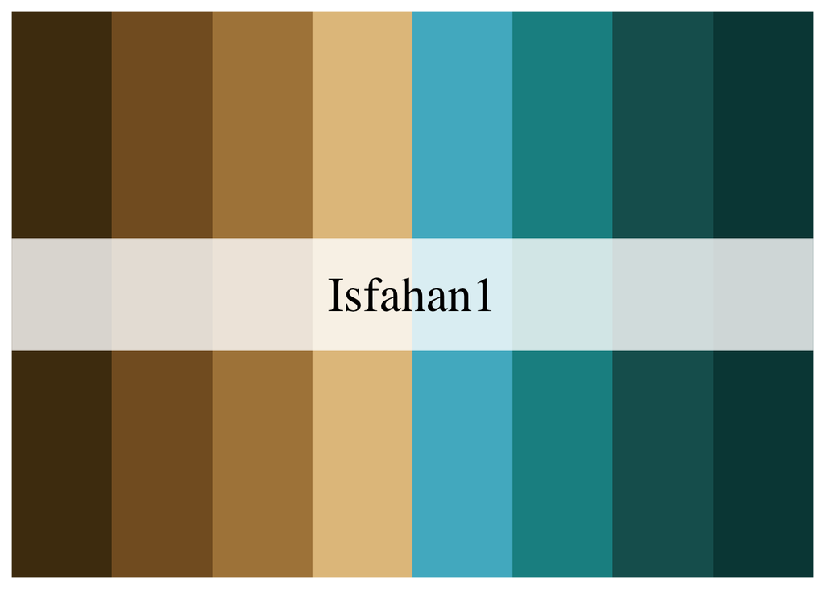

```r
met.brewer("Isfahan1") #this one is colorblind friendly and has 8 colors
```

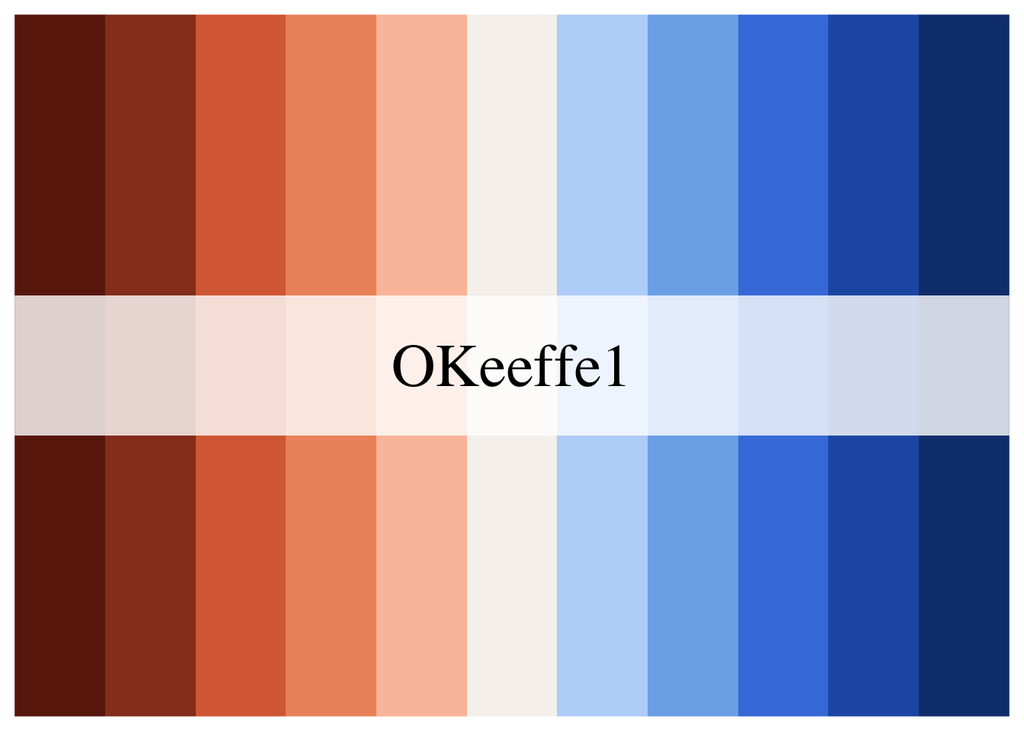

```r
met.brewer("OKeeffe1")
```

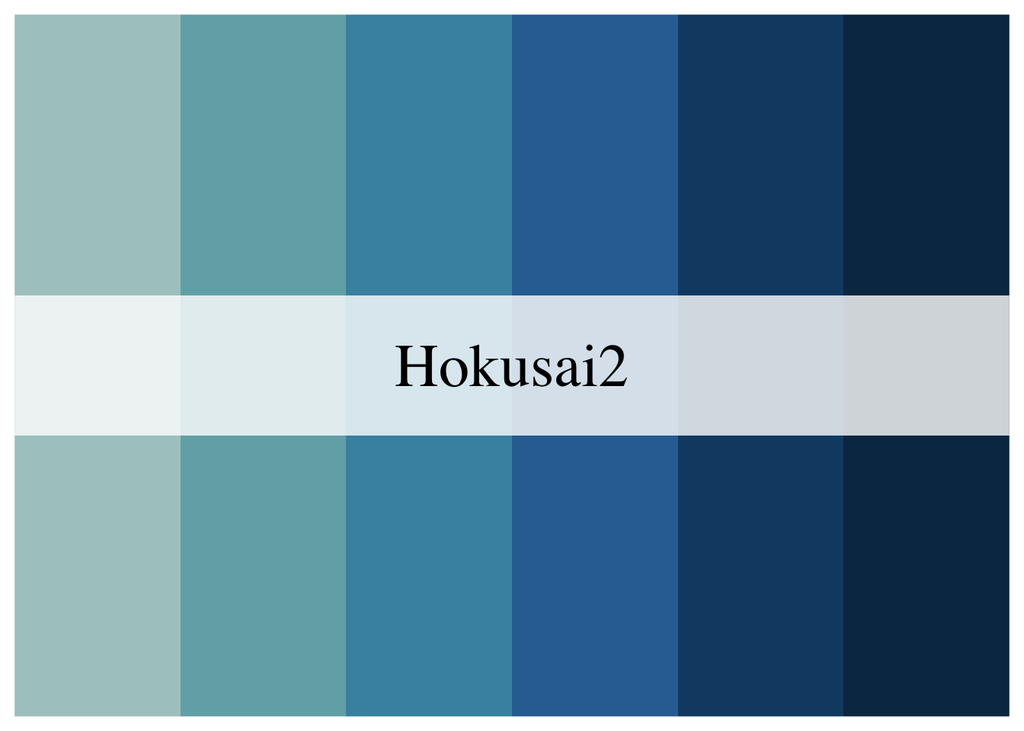

```r
met.brewer("Hokusai2")
```

Using the MetBrewer package to visualize the percentage of olive oil fatty acid compounds.

```r
data("olive")
View(olive) #data on percentage of 8 fatty acids found in the lipid fraction of 572 olive oils
```

This dataset has the percentage of 8 different fatty acids found in the lipid fraction of 572 olive oils from regions around Italy. We need a palette that has 8 distinct colors, so I’ve picked the Isfahan1 palette, which is based on colors found in a beautiful mosaic Mihrab or pray niche from twelfth century Iran.

```r
#first tidy the data by making it so the fatty acid types are long form
olive.melt <- reshape2::melt(olive, id = c("region", "area"), #the columns we want as the identifiers - everything else will be transposed into long format
                             value.name = "Percent", #renaming the value column
                             variable.name = "fatty_acid") #renaming the variable column
```

Now that the data is tidied with the melt function, turning it from wide to long format.

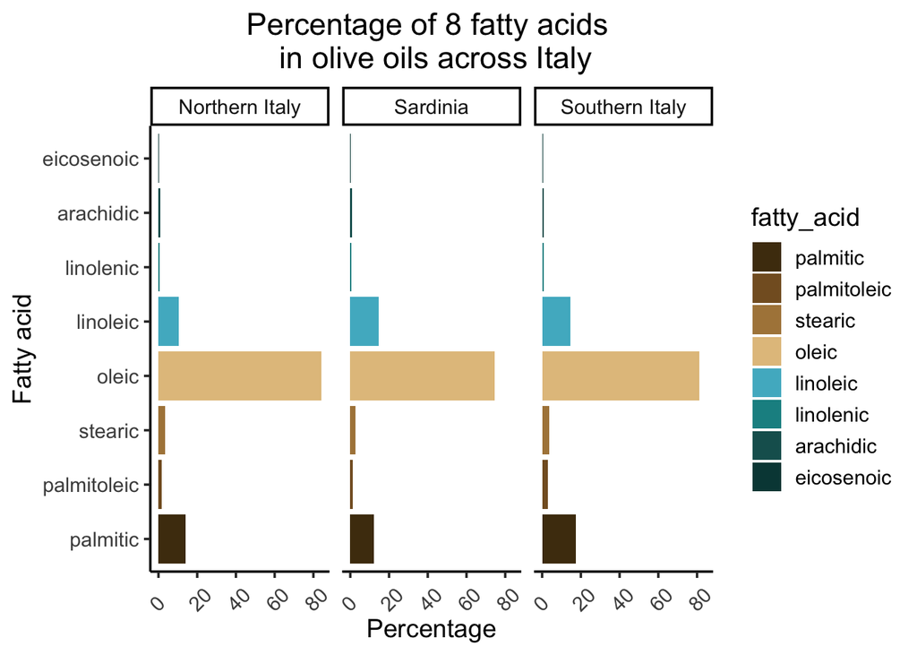

```r
ggplot(olive.melt, aes(x= fatty_acid, y= Percent, fill = fatty_acid)) +
  geom_bar(stat = "identity", position = "dodge")+
  xlab("Fatty acid") +
  ylab( "Percentage") +
  facet_wrap(~region) +
  coord_flip() + #flip it and reverse it
  theme_classic(base_size = 14) +
  theme(axis.text.x = element_text(angle = 45,
                                   hjust = 0, vjust = 0)) +
          ggtitle("Percentage of 8 fatty acids \n in olive oils across Italy") +
  scale_fill_manual(values=met.brewer("Isfahan1")) +
  theme(plot.title = element_text(hjust = 0.5)) # center the text
```

### Studio Ghibli

This package contains palettes inspired by the colors in 8 different Studio Ghibli movies, with light and dark variations for each.

https://github.com/ewenme/ghibli

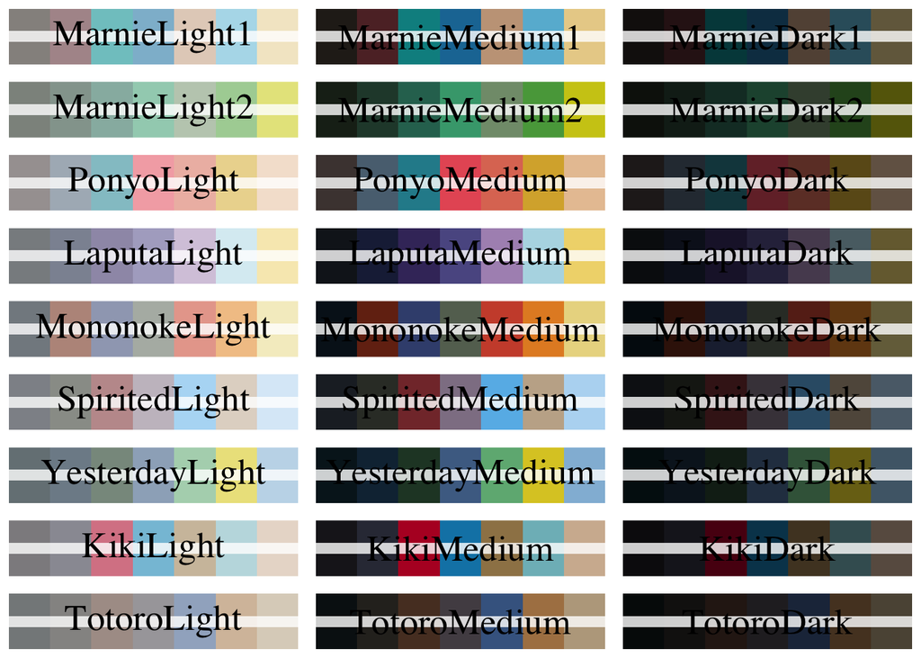

```r
# display palettes with names
par(mfrow=c(9,3))
for(i in names(ghibli_palettes)) print(ghibli_palette(i))
```

### A few more themes to peruse at your convenience

#### National Parks

25 palettes based on vintage posters by the US Department of the Interior/National Parks Services.

https://github.com/katiejolly/nationalparkcolors

#### ggsci

Color palettes inspired by the color schemes of journals, data viz libraries, science fiction movies and TV shows such as Rick and Morty and StarTrek.

https://cran.r-project.org/web/packages/ggsci/vignettes/ggsci.html

#### ggthemes

Used earlier for our themes, ggthemes also has its own built-in color palettes, based on such things as Excel, Stata, the Economist, the Wall Street Journal, and more.

#### LaCroix

Palettes for every flavor of your favorite bubbly water.

https://github.com/johannesbjork/LaCroixColoR

#### ochRe

Palettes inspired by the art, landscapes, and wildlife of Australia.

https://github.com/hollylkirk/ochRe

#### Palettetown

Pokemon-inspired palettes!

https://github.com/timcdlucas/palettetown

#### scico

A lot of the previous ones are for discrete scales - this one has great options for continuous scales, all of which are colorblind-friendly.

https://github.com/thomasp85/scico

## For Fun: Animating Plots

Using the gganimate package, which provides a new layer to add on to ggplot! Good for visualization of time series data in which you also want to visualize other variables - in this case, life expectancy vs GDP over time, faceted by continent.

https://gganimate.com/

```r
data("gapminder") #health and income outcomes for 184 countries from 1960 to 2016
View(gapminder)
```

First let’s see what it looks like if we just plot it as a scatter plot of gdp vs life expectancy, with each dot’s size representing the population.

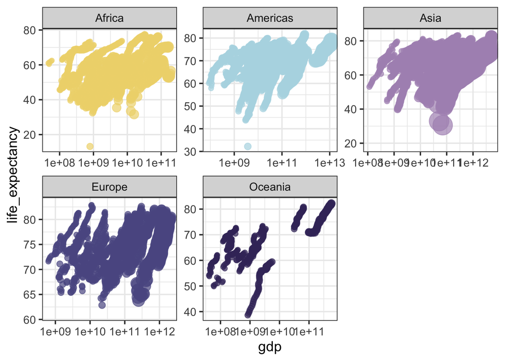

```r
ggplot(gapminder, aes(x = gdp, y = life_expectancy, size = population, color = continent))+
  geom_point(alpha = 0.7, show.legend = FALSE) +
  scale_size(range = c(2, 12)) +
  scale_color_ghibli_d("LaputaMedium", direction = -1) +
  facet_wrap(~continent, scales = "free") +
  theme_bw(base_size = 14)+
  scale_x_log10()
```

This is pretty messy - there are so many points from over the years that it’s difficult to visualize the trends.

Now adding in the animation layers:

```r
ggplot(gapminder, aes(x = gdp, y = life_expectancy, size = population, color = continent)) +
  geom_point(alpha = 0.7, show.legend = FALSE) +
  scale_size(range = c(2, 12)) +
  scale_color_ghibli_d("LaputaMedium", direction = -1) + #using the Studio Ghibli palette
  facet_wrap(~continent, scales = "free") +
  theme_bw(base_size = 14) +
  scale_x_log10() + # convert to log scale
  labs(title = 'Year: {frame_time}', x = 'GDP per capita', y = 'life expectancy') + #gganimate specific
  transition_time(year) + #defines that the data will be spread out by the 'year' variable
  ease_aes('linear') #the animation 'style' - how the aesthetics will be eased during the transition
```

To save your animated plot, you can use the function anim_save(), which is analagous to ggsave but saves the rendered animation as a .gif file.

## Palettes for data with a large number of variables

A challenge with datasets that have a large number (>10) of variables is how to color them in a way that is distinguishable. The ‘pals’ package provides a number of large palette options and is compatible with ggplot2.

First load in the data for gapminder from the dslabs package

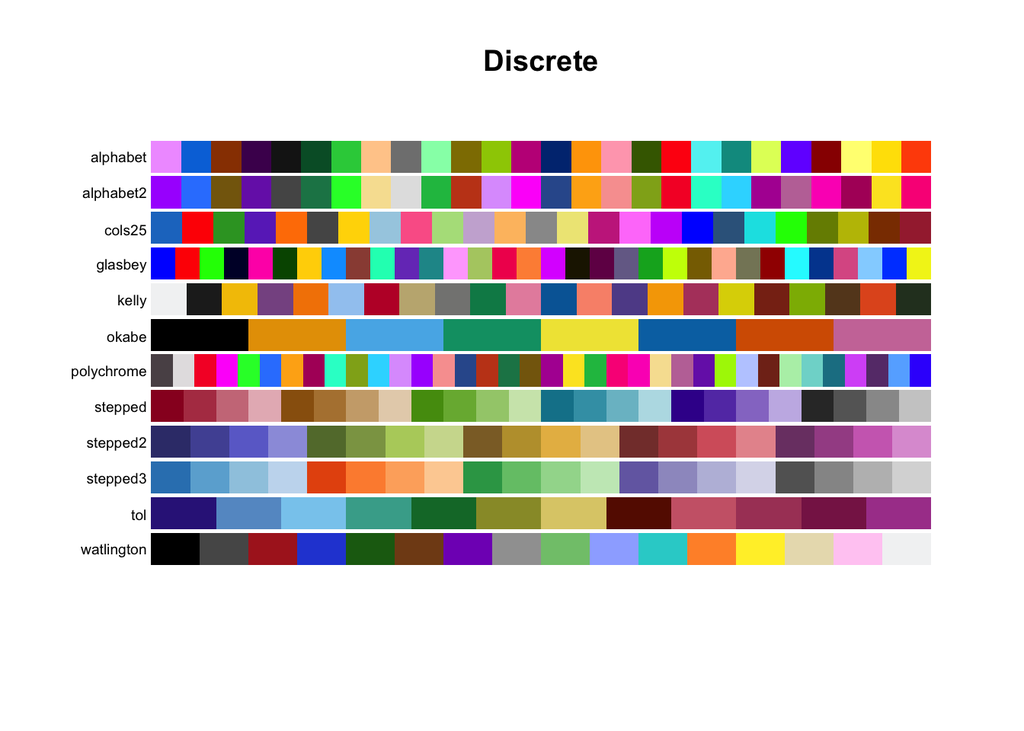

```r
# look at the palettes
# Discrete
pal.bands(alphabet, alphabet2, cols25, glasbey, kelly, okabe, polychrome, stepped, stepped2, stepped3, tol, watlington,
          main="Discrete", show.names=FALSE)
```

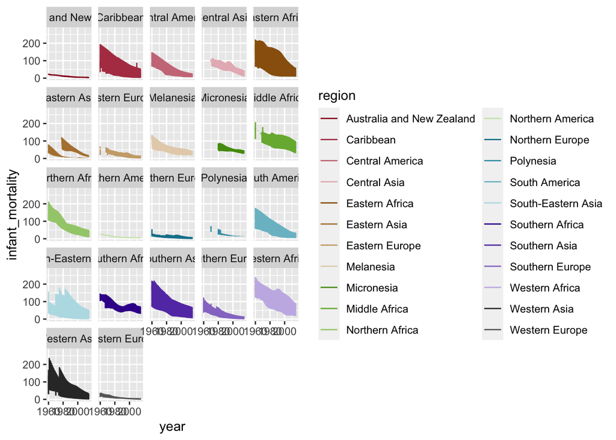

```r
ggplot(data = gapminder, aes(x = year, y =infant_mortality)) +
  geom_line(aes(color = region)) +
  facet_wrap(~ region)+
  scale_color_manual(values=as.vector(stepped(22)))
```

## A little microbiome fun

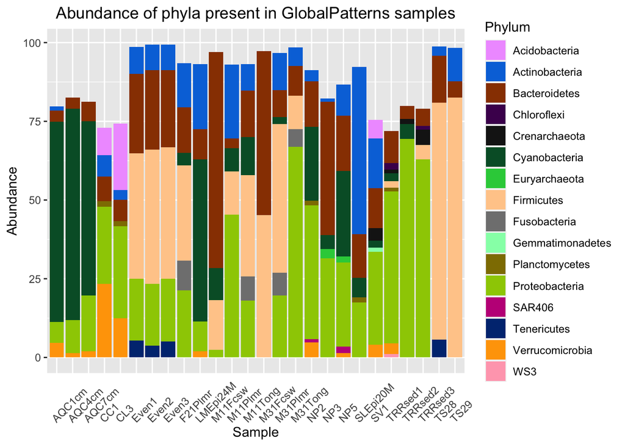

```r
data("GlobalPatterns") #using a built in dataset from the phyloseq package

# Transform to relative abundance
gp.norm <- transform_sample_counts(GlobalPatterns, function(x) 100 * x/sum(x))

# Compile taxa by Order (filtering out low abundance taxa)
gp.order <- gp.norm  %>%
  tax_glom(taxrank = "Order") %>%                     # agglomerate taxa at order level
  psmelt() %>%                                        # Melt phyloseq object to long format for producing graphics with ggplot2
  filter(Abundance > 1.0)  %>%                        # Filter out orders below 1% in each sample
  arrange(desc(Phylum),desc(Class),desc(Order))

# Sum remaining taxa with a relative abundance < 1% and make a new dataframe
Remainders <- (gp.order) %>%
  group_by(SampleType) %>%
  summarise(Abundance = (100-sum(Abundance))) %>%
  as.data.frame()
Remainders$Order<-"Orders < 1%"
Remainders$Phylum<-"_Orders < 1%"
Remainders$Class<-"_Orders < 1%"
Remainders$Kingdom<-"Bacteria"

# Join dataframes
gp.barchart <- full_join(gp.order,Remainders)

# reorder based on phylogeny
gp.barchart <- gp.barchart[with(gp.barchart, order(Phylum,Class,Order)),]
gp.barchart <- na.omit(gp.barchart)

ggplot(data = gp.barchart, aes(x = Sample, y = Abundance, fill = Phylum)) +
  geom_bar(aes(), stat = "identity", position = "stack") +
  scale_fill_manual(values=as.vector(alphabet(16))) +
  theme(axis.text.x = element_text(angle = 45,
                                   hjust = 0, vjust = 0),
        axis.line = element_blank(), #removing the axis lines
        axis.ticks.x = element_blank()) + #removing the axis ticks along the x axis
          ggtitle("Abundance of phyla present in GlobalPatterns samples") +
  theme(plot.title = element_text(hjust = 0.5)) # center the text
```